# Project 1

December 11, 2018

### Background

The data that I am using is a dataset from Kickstarter (a crowdfunding platform) with over 30,000 kickstarter projects. The dataset has been filtered to include kickstarter projects that were only funded in US dollars. This dataset came from Kaggle and can be found through the following link: https://www.kaggle.com/kemical/kickstarter-projects

### Question and Hypothesis

Question 1: Does each category of kickstarter projects have pledged amounts that come from the same distribution? (i.e. does one of the kickstarter projects average pledged amount asked for exceed that of other project’s)

$$H_o: \mu_{category1} = \mu_{category2} ... = \mu_{category15}$$

$$H_a: \mu_i ≠ \mu \ for \ at \ least \ one \ i$$

Question 2: Does each state of kickstarter projects have pledged (funds raised for the project) amounts that come from the same distribution?

$$H_o: \mu_{success} = \mu_{failure} = \mu$$

$$H_a: \mu_i ≠ \mu \ for \ at \ least \ one \ i \ \epsilon \left\{ 1=success,\ 2 = failure\right\}$$

Question 3: Is there a correlation between the goal amount and the amount that was pledged?

$$H_o: \beta_1 = 0$$

$$H_a: \beta_1≠ 0$$
$$\alpha = .05$$
###Prep the data

```r
dat_kickstarter2 <- subset(dat_kickstarter, dat_kickstarter$state == "failed" | dat_kickstarter$state == "successful")

dat_kickstarter2 <- dat_kickstarter2 %>%
  filter(currency == "USD", pledged > 0)
```

### Category and the amounts pledged

```r
pander(kruskal.test(pledged ~ as.factor(main_category), data= dat_kickstarter2))
```

Kruskal-Wallis rank sum test: `pledged` by `as.factor(main_category)`

| Test statistic | df | P value |
| --- | --- | --- |
| 9008 | 14 | 0 * * * |

All of the values are significant, which shows that both the project’s state as well as the category help to determine the amount pledged.

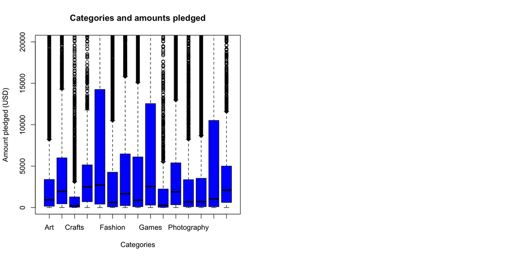

```r
options(scipen=999)
par(mfrow=c(1,2))
  boxplot(pledged ~ as.factor(main_category), data = dat_kickstarter2, type=c("p","a"), ylim = c(0,20000), xlab = "Categories", ylab = "Amount pledged (USD)", main = "Categories and amounts pledged", col = "blue")
```

From the graphs above it is apparent that the design, games, and the tech are the top 3 categories that get the most amount pledged. According to the p value from the kruskal test above, this is significant.

### States of the project and the amounts pledged

```r
pander(kruskal.test(pledged ~ as.factor(state), data= dat_kickstarter2))
```

Kruskal-Wallis rank sum test: `pledged` by `as.factor(state)`

| Test statistic | df | P value |
| --- | --- | --- |
| 105278 | 1 | 0 * * * |

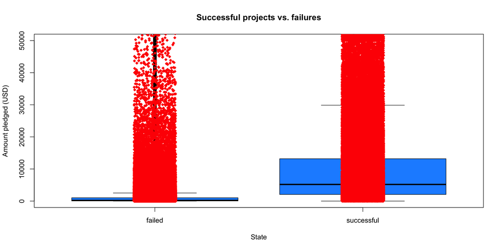

```r
boxplot(pledged ~ as.factor(state), data = dat_kickstarter2, type=c("p","a"), ylim = c(0,50000), xlab = "State", ylab = "Amount pledged (USD)", main = "Successful projects vs. failures", col = "dodgerblue", jitter.data = T)
stripchart(pledged ~ as.factor(state), data = dat_kickstarter2, vertical = TRUE, method = "jitter", add = TRUE, pch = 18, col = 'red')
```

The outcome of the project and the amount pledged is also significant. The successful projects typically have more money pledged to them, this makes sense since those projects that are worth funding are probably going to attract more attention and money. The definition of success and failure is that if a project is successful, the project is built/occurs and if it is a failure, then funders get their money back.

### Appropriatness of the data

It is important to check if the data is normal or not, since if it was normal, then an ANOVA test would have been more appropriate.

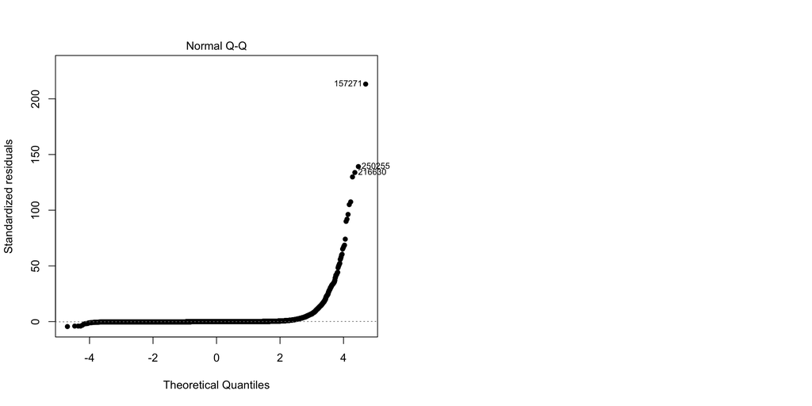

```r
par(mfrow=c(1,2))
myaov <- aov(pledged ~ main_category + goal + main_category:goal, data= dat_kickstarter)
plot(myaov, which= 2, pch=16)
```

As you can see from the diagnostic chart above, the Kruskal Wallis test was appropriate.

### Linear regression of goal and amount pledged

```r
options(scipen=999)
plot(goal ~ pledged, data = dat_kickstarter2, xlab = "Amount pledged (USD)", ylab = "Goal amount (USD)", ylim = c(0,1000000), xlim = c(0,5000000))
my_lm <- lm(goal ~ pledged, data = dat_kickstarter2)
pander(summary(my_lm))
```

Table continues below

|  | Estimate | Std. Error | t value |
| --- | --- | --- | --- |
| **(Intercept)** | 33032 | 1927 | 17.14 |
| **pledged** | 0.07533 | 0.01727 | 4.362 |

|  | Pr(>\|t\|) |
| --- | --- |
| **(Intercept)** | 0.000000000000000000000000000000000000000000000000000000000000000008353 |
| **pledged** | 0.0000129 |

Fitting linear model: goal ~ pledged

| Observations | Residual Std. Error | $R^2$ | Adjusted $R^2$ |
| --- | --- | --- | --- |
| 232620 | 924356 | 0.00008178 | 0.00007748 |

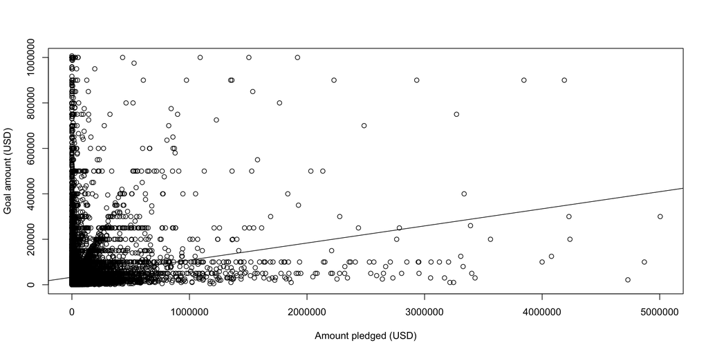

```r
abline(my_lm)
```

### Conclusion

I was surprised to see that all of the values were significant in the dataset. The categories came from different distributions in the end, which is what I expected, I just wasn’t sure which categories would be most popular (technology was one I guessed, but I would have never guessed design). Also I wasn’t expecting the relationship between the goal and amount pledged to be so right skewed either. Finally, it did make sense that the successful project would get, on average, more funds given to them.